# Prática 4: Intervalos de Confiança

Guilherme Rodrigues

21 de fevereiro de 2026

```r
options(encoding = "UTF-8")
#limpar a memória
rm(list = ls())
```

## Importando os dados

```r
library(readxl)
data_ex1 <- read_excel("dados.xlsx", sheet = "Ex1")
head(data_ex1)
```

| ID | Idade | Sexo | Resultado |
| --- | --- | --- | --- |
| 14396 | 51 | Masculino | Positivo |
| 15139 | 50 | Feminino | Positivo |
| 15542 | 47 | Feminino | Positivo |
| 13827 | 42 | Feminino | Positivo |
| 15215 | 50 | Feminino | Positivo |
| 15253 | 46 | Feminino | Positivo |

```r
Idade = data_ex1$Idade
qtd_pacientes = length(Idade)
summary(Idade)
```

```
##    Min. 1st Qu.  Median    Mean 3rd Qu.    Max.
##   33.00   46.00   50.00   49.76   53.00   66.00
```

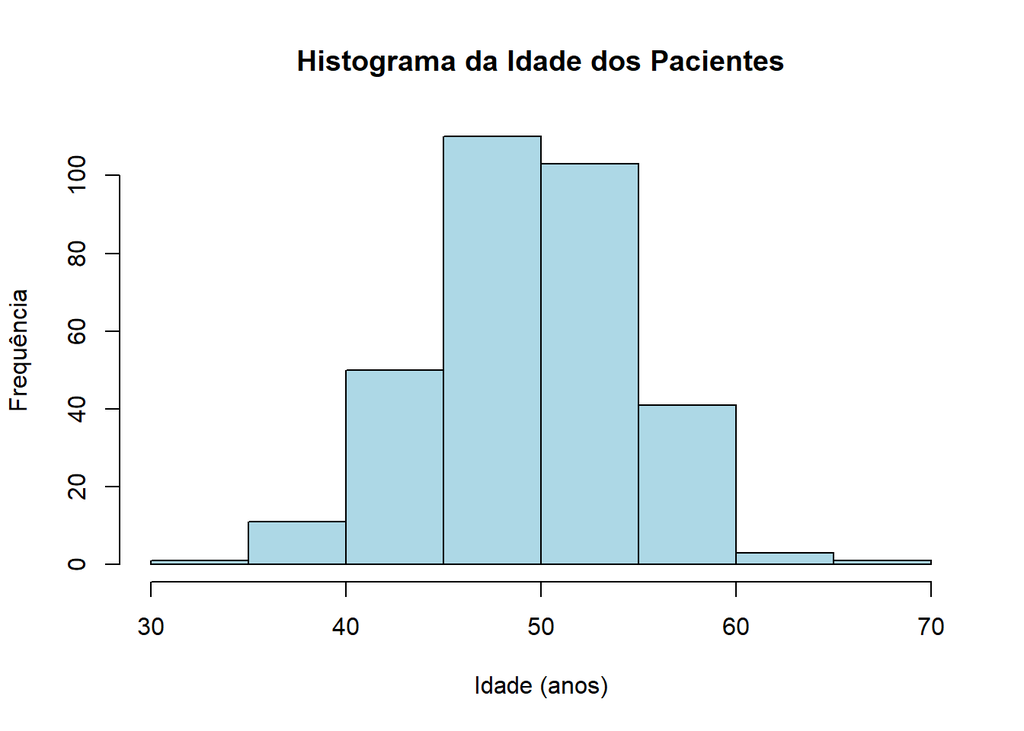

```r
hist(Idade, main = "Histograma da Idade dos Pacientes",
     ylab = "Frequência", xlab = "Idade (anos)",
     col = "lightblue", border = "black")
```

**1)** Um experimento avaliou o desempenho de uma pomada medicinal natural para o tratamento de feridas dermatológicas.

**a)** Calcule o intervalo de confiança de 95% para a idade média dos pacientes deste estudo.

**Resposta:** Como temos uma população de 320 pacientes, podemos utilizar a distribuição normal para calcular o intervalo de confiança de 95% para a idade média dos pacientes.

```r
mu <- round(mean(Idade), 3)
sigma <- round(sd(Idade), 3)
print(paste("Média: ", mu))
```

```
## [1] "Média:  49.756"
```

```r
print(paste("Desvio Padrão: ", sigma))
```

```
## [1] "Desvio Padrão:  5.181"
```

```r
erro <- qnorm(0.975) * (sigma / sqrt(qtd_pacientes))
lower_bound <- mu - erro
upper_bound <- mu + erro
cat("Intervalo de Confiança de 95% para a idade média dos pacientes: [",
    round(lower_bound, 2), ", ", round(upper_bound, 2), "]\n")
```

```
## Intervalo de Confiança de 95% para a idade média dos pacientes: [ 49.19 ,  50.32 ]
```

Portanto, o intervalo de confiança de 95% para a idade média dos pacientes é aproximadamente [49.19, 50.32] anos.

De outro modo, podemos utilizar a distribuiução t-student, a qual se mostra mais conservadora e se aproxima da normal conforme o tamanho da amostra aumenta, em nosso caso, uma amostra de 320 pacientes é mais do que suficiente. Podemos utilizar o fato de que os 320 pacientes são uma amostra de uma população maior, e assim utilizar a t-student para calcular o intervalo de confiança. Segue que:

```r
t <- qt(0.975, df = qtd_pacientes - 1)
c(lower = mu - t*(sigma / sqrt(qtd_pacientes)),
  upper = mu + t*(sigma / sqrt(qtd_pacientes)))
```

```
##    lower    upper
## 49.18618 50.32582
```

Podemos notar neste caso que o intervalo de confiança de 95% para a idade média dos pacientes é aproximadamente [49.18, 50.32] anos, o que é muito próximo (quase idêntico) do valor obtido utilizando a distribuição normal.

**b)** Apresente um intervalo de confiança de 95% para a proporção de resultado positivo deste tratamento e verifique se a eficácia é superior a 80%.

**Resposta:** Para calcular o intervalo de confiança de 95% para a proporção de resultado positivo do tratamento, podemos utilizar a fórmula do intervalo de confiança para proporções.

```r
resultado_positivo <- sum(data_ex1$Resultado == "Positivo")
p_hat <- resultado_positivo / qtd_pacientes
erro_proporcao <- qnorm(0.975) * sqrt((p_hat * (1 - p_hat)) / qtd_pacientes)
lower_bound_prop <- p_hat - erro_proporcao
upper_bound_prop <- p_hat + erro_proporcao
cat("Intervalo de Confiança de 95% para a proporção de resultado positivo: [",
    round(lower_bound_prop, 4), ", ",
    round(upper_bound_prop, 4), "]\n")
```

```
## Intervalo de Confiança de 95% para a proporção de resultado positivo: [ 0.8493 ,  0.9194 ]
```

Portanto, o intervalo de confiança de 95% para a proporção de resultado positivo do tratamento é aproximadamente [0.8493 , 0.9194]. Como o limite inferior do intervalo de confiança (0.8493) é maior que 0.80, podemos concluir que a eficácia do tratamento é superior a 80%.

**2)** Um levantamento deseja estudar as características de morcegos de uma região com o objetivo de verificar se o peso médio é superior a 100 gramas. A partir da amostra dos morcegos, calcule o intervalo de confiança de 95% para o peso médio dos morcegos e verifique o objetivo do estudo.

**Resposta:** Como temos uma quantidade inferior a 30 morcegos, devemos utilizar a distribuição t-student para calcular o intervalo de confiança de 95% para o peso médio dos morcegos. Segue que:

```r
data_ex2 <- read_excel("dados.xlsx", sheet = "Ex2e3")
head(data_ex2)
```

| Insetivoro | Hematofago |
| --- | --- |
| 104.0 | 116.1 |
| 111.4 | 120.3 |
| 115.4 | 114.8 |
| 108.3 | 119.4 |
| 112.1 | 117.4 |
| 112.5 | 115.4 |

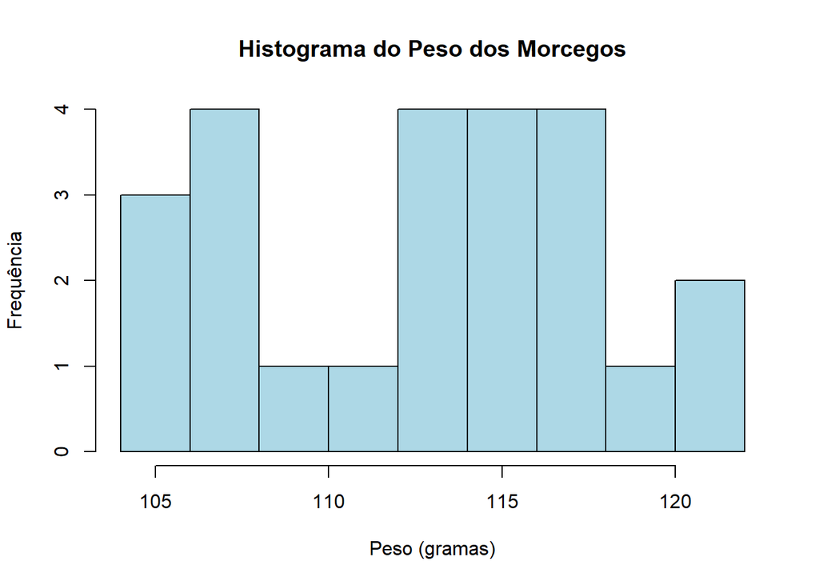

```r
pesos <- c(data_ex2$Insetivoro, data_ex2$Hematofago)
hist(pesos, main = "Histograma do Peso dos Morcegos",
     ylab = "Frequência", xlab = "Peso (gramas)",
     col = "lightblue", border = "black")
```

```r
summary(pesos)
```

```
##    Min. 1st Qu.  Median    Mean 3rd Qu.    Max.
##   104.0   107.5   112.4   112.6   116.4   120.7
```

```r
n_pesos <- length(pesos)

mu_pesos <- mean(pesos)
sigma_pesos <- sd(pesos)

erro_pesos <- qt(0.975, df = n_pesos - 1) * (sigma_pesos / sqrt(n_pesos))
lower_bound_pesos <- mu_pesos - erro_pesos
upper_bound_pesos <- mu_pesos + erro_pesos

cat("Intervalo de Confiança de 95% para o peso médio dos morcegos: [",
    round(lower_bound_pesos, 2), ", ",
    round(upper_bound_pesos, 2), "]\n")
```

```
## Intervalo de Confiança de 95% para o peso médio dos morcegos: [ 110.46 ,  114.79 ]
```

De fato, o intervalo de confiança de 95% para o peso médio dos morcegos é aproximadamente [110.46, 114.79] gramas. Como o limite inferior do intervalo de confiança é maior que 100 gramas, podemos concluir que o peso médio dos morcegos é superior a 100 gramas, atendendo ao objetivo do estudo.

**3)** Utilizando os dados do exercício anterior, compare a variância do peso dos morcegos insetívoros e hematófagos por meio de intervalo de confiança. Com este resultado, calcule o intervalo de confiança de 95% da diferença dos pesos médios entre os insetívoros e hematófagos.

**Resposta:** Para comparar a variância do peso dos morcegos insetívoros e hematófagos, podemos utilizar o intervalo de confiança para a razão das variâncias. Segue que:

```r
insetivoro <- data_ex2$Insetivoro
hematofago <- data_ex2$Hematofago
s1 <- sd(insetivoro)
s2 <- sd(hematofago)
n1 <- length(insetivoro)
n2 <- length(hematofago)

R <- s1^2/s2^2

lower_var <- R / qf(0.975, df1 = n1-1, df2 = n2-1)
upper_var <- R / qf(0.025, df1 = n1-1, df2 = n2-1)


cat("Intervalo de Confiança de 95% para a razão das variâncias: [",
    round(lower_var, 4), ", ",
    round(upper_var, 4), "]\n")
```

```
## Intervalo de Confiança de 95% para a razão das variâncias: [ 0.4452 ,  5.3717 ]
```

Como o intervalo de confiança para a razão das variâncias é aproximadamente [0.4452 , 5.3717], e este intervalo inclui o valor 1, não podemos concluir que há uma diferença significativa entre as variâncias dos pesos dos morcegos insetívoros e hematófagos. Com este resultado, podemos assumir que as variâncias são iguais e calcular o intervalo de confiança de 95% para a diferença dos pesos médios entre os insetívoros e hematófagos utilizando a fórmula do intervalo de confiança para a diferença de médias com variâncias iguais. Segue que:

```r
mu_insetivoro <- mean(insetivoro)
mu_hematofago <- mean(hematofago)
print(paste("Média Insetívoros: ", round(mu_insetivoro, 3)))
```

```
## [1] "Média Insetívoros:  108.617"
```

```r
print(paste("Média Hematófagos: ", round(mu_hematofago, 3)))
```

```
## [1] "Média Hematófagos:  116.633"
```

```r
var_conjunta <- (((n1 - 1) * s1^2) + ((n2 - 1) * s2^2)) / (n1 + n2 - 2)
se <- sqrt(var_conjunta * (1/n1 + 1/n2))
t_value <- qt(0.975, df = n1 + n2 - 2)
lower_dif <- (mu_insetivoro - mu_hematofago) - t_value * se
upper_dif <- (mu_insetivoro - mu_hematofago) + t_value * se

cat("Intervalo de Confiança de 95% para a diferença dos pesos médios entre
    insetívoros e hematófagos: [",
    round(lower_dif, 3), ", ",
    round(upper_dif, 3), "]\n")
```

```
## Intervalo de Confiança de 95% para a diferença dos pesos médios entre
##     insetívoros e hematófagos: [ -10.681 ,  -5.353 ]
```

Portanto, o intervalo de confiança de 95% para a diferença dos pesos médios entre os morcegos insetívoros e hematófagos é aproximadamente [-10.68 , -5.35] gramas. Como o intervalo de confiança não inclui o valor 0, podemos concluir que há uma diferença significativa entre os pesos médios dos morcegos insetívoros e hematófagos, com os hematófagos sendo mais pesados em média.